# GARCH Model Selection and Forecasting

Install and load packages and data.

```r
packages = c('forecast','quantmod','rugarch','urca','WeightedPortTest')
for(package in packages){
  if(!require(package,character.only=TRUE,quietly=TRUE)){
    install.packages(package,repos='http://cran.us.r-project.org')
    require(package,character.only=TRUE,quietly=TRUE)
  }
}
```

```
## Version 0.4-0 included new data defaults. See ?getSymbols.
```

```r
rm(list = ls(all.names = TRUE))
source("GARCH_RFunctions.R")
load("final.RData")
```

```r
#examine object names in RData file
ls()
```

```
## [1] "autoplot_roots" "ic.fun"         "plot_roots"     "showShort"
## [5] "syb"            "Yt"
```

Yt object contains the daily returns of 4 assets in percentage form (for numerical stability) from 2011- 01-04 to 2020-04-29. Their ticker symbols can be found in the object `syb`. The first 3 companies, EOG Resources (EOG), Halliburton (HAL) and Chevron (CVX), are oil industry companies. The last one is Amazon (AMZN).

Plotting each return series of Yt.

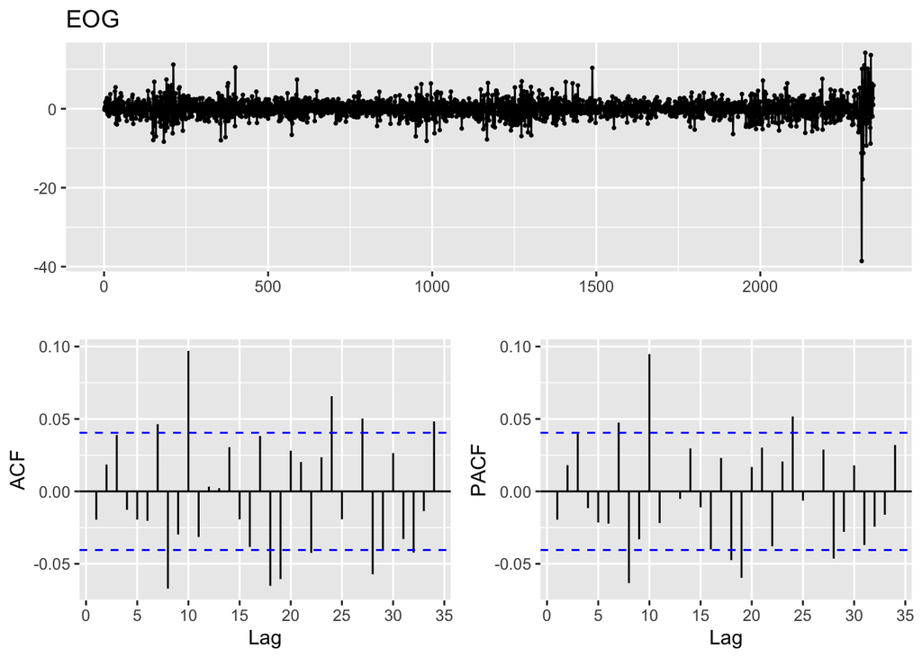

```r
ggtsdisplay(Yt[,"EOG"], main = "EOG")
```

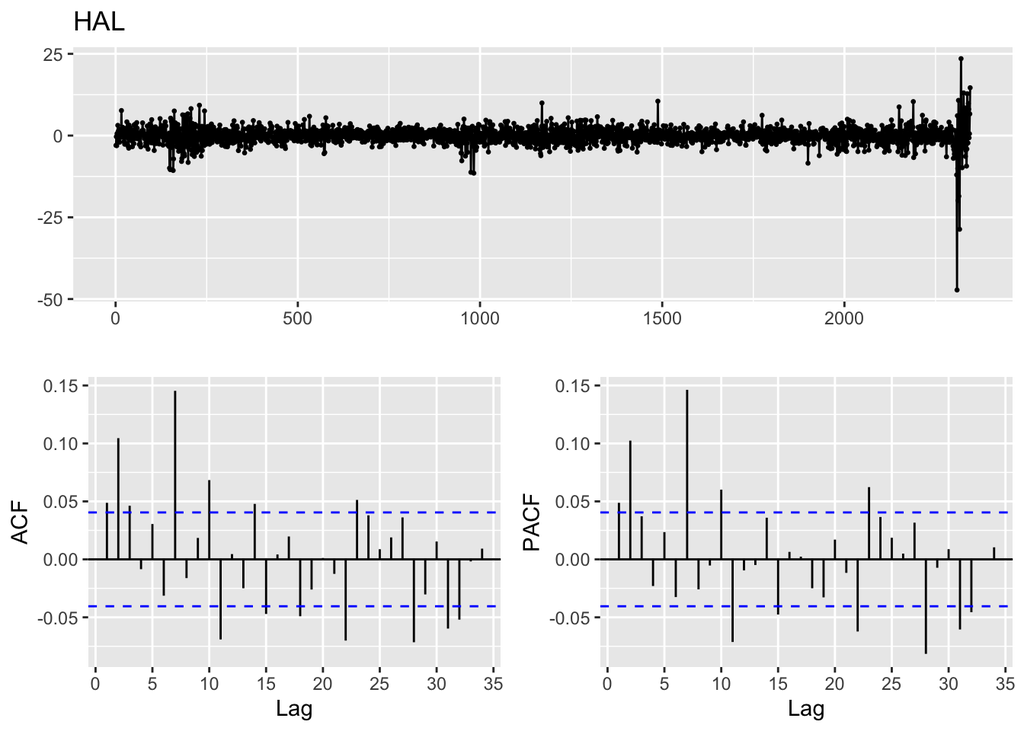

```r
ggtsdisplay(Yt[,"HAL"], main = "HAL")
```

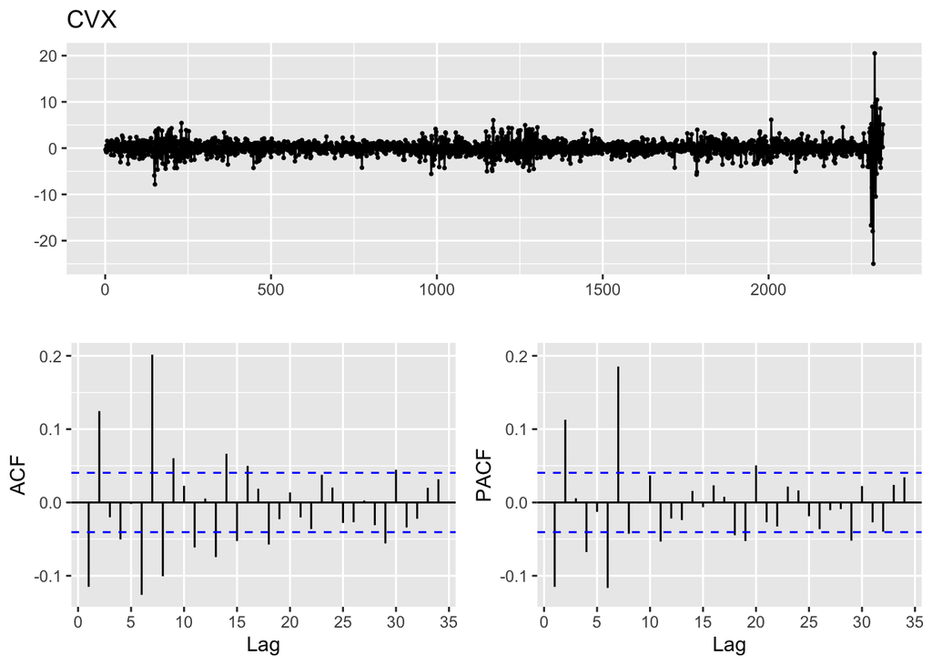

```r
ggtsdisplay(Yt[,"CVX"], main = "CVX")
```

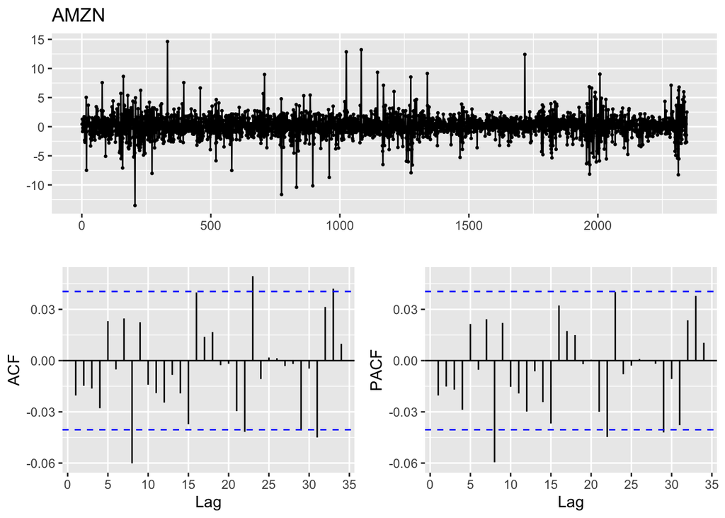

```r
ggtsdisplay(Yt[,"AMZN"], main = "AMZN")
```

The time series plots of the oil industry companies’ returns appear almost exactly the same. They have the same appearance of no linear trend or intercept and a large amount of volatility around present day (oil prices have been volatile and fallen recently), which indicates GARCH effects may need to be taken into account. The time series and ACF plots of all the oil companies indicate stationarity because there are no apparent linear trends and the mean appears to be 0 (no intercept) and their ACFs have relatively fast decaying ACFs.

The Amazon series has no such extreme volatility recently. But like the oil companies, it appears to have a mean of 0. Amazon’s ACF shows evidence of white noise because almost all of its ACF are within the 95% bands.

I’m choosing the Chevron (CVX) return series to model and analyze.

```r
Rt = Yt[,"CVX"]
n = dim(Rt)[1] #sample size
N = dim(Rt)[2] #number of assets
```

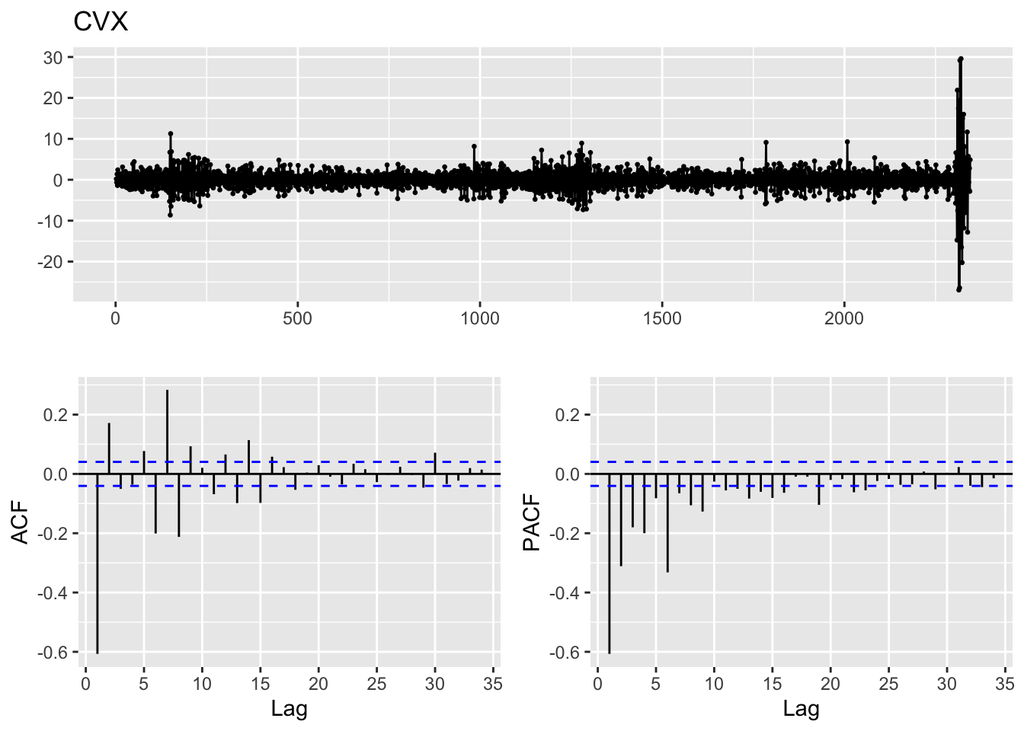

```r
#plot CVX differenced series
dYt = diff(Yt[,"CVX"])
ggtsdisplay(dYt, main = "CVX")
```

The differenced series ACF shows fast decay of its ACF, which indicates the differenced series is stationary.

There’s no evidence of non-stationarity. ADF Unit root tests are unnecessary, but are shown below to confirm.

Using AIC:

```r
#run ADF tests on raw series
p.max = trunc(12*(n/100)^0.25);cat("Maximum lags for the AIC:\t", p.max)
```

```
## Maximum lags for the AIC:     26
```

```r
DF = ur.df(Rt, type = "none", lag = p.max, selectlags = "AIC"); DF
```

```
##
## ###############################################################
## # Augmented Dickey-Fuller Test Unit Root / Cointegration Test #
## ###############################################################
##
## The value of the test statistic is: -11.0942
```

```r
cat("The ADF statistic is:\t", DF@teststat[1],"\nModel with no drift or trend and
lag parameter p =", DF@testreg$df[1]-2, "by the m-AIC");
```

```
## The ADF statistic is:     -11.09416
## Model with no drift or trend and
## lag parameter p = 20 by the m-AIC
```

```r
cat("\nCritical value:\n");DF@cval[1,]
```

```
##
## Critical value:
```

```
##  1pct  5pct 10pct
## -2.58 -1.95 -1.62
```

Using BIC:

```r
DF = ur.df(Rt, type = "none", lag = p.max, selectlags = "BIC"); DF
```

```
##
## ###############################################################
## # Augmented Dickey-Fuller Test Unit Root / Cointegration Test #
## ###############################################################
##
## The value of the test statistic is: -16.9253
```

```r
cat("The ADF statistic is:\t", DF@teststat[1],"\nModel with no drift or trend and
lag parameter p =", DF@testreg$df[1]-2, "by the BIC");
```

```
## The ADF statistic is:     -16.92526
## Model with no drift or trend and
## lag parameter p = 5 by the BIC
```

```r
cat("\nCritical value:\n");DF@cval[1,]
```

```
##
## Critical value:
```

```
##  1pct  5pct 10pct
## -2.58 -1.95 -1.62
```

ADF Unit root test H0 states: Series is non-stationary.

Raw series: Reject H0 because test statistic is more extreme than 5pct critical value, which indicates raw series is stationary I(0).

```r
KPSS = ur.kpss(Rt, type = "mu")
cat("The KPSS statistic is:\t", KPSS@teststat);
```

```
## The KPSS statistic is:    0.06154113
```

```r
cat("The lag parameter of the Newey-West estimator is:\t", KPSS@lag);KPSS@cval
```

```
## The lag parameter of the Newey-West estimator is:     8
```

```
##                 10pct  5pct 2.5pct  1pct
## critical values 0.347 0.463  0.574 0.739
```

Do not reject H0: Series is stationary.

Find a distribution that is the best fit from the t, skewed-t, GED, and skewed-GED distributions.

```r
dists = c("std", "sstd", "ged", "sged")
fits = vector("list", 4)
for(i in 1:4) fits[[i]] = fitdist(dists[i], Rt)

AIC = vector("list", 4)
BIC = vector("list", 4)
loglik = vector("list", 4)
for(i in 1:4){
# negative log likelihood:
  loglik[[i]] = fits[[i]]$values[length(fits[[i]]$values)]
  p = 3
  n = length(Rt)
  AIC[i] = 2*loglik[[i]] + 2 * p
  BIC[i] = 2*loglik[[i]] + log(n) * p

}
names(loglik) = dists
names(AIC) = dists
names(BIC) = dists
rbind(AIC, BIC)
```

```
##     std      sstd     ged      sged
## AIC 8043.211 8041.586 8147.295 8142.371
## BIC 8060.491 8058.866 8164.575 8159.651
```

AIC and BIC are non-negative. Skewed t-distribution minimizes AIC and BIC, so this appears to be the best distribution.

```r
#SSTD estimated parameters
fits[[2]]$pars
```

```
##         mu      sigma       skew      shape
## 0.02035252 1.70265469 0.96504809 2.82892353
```

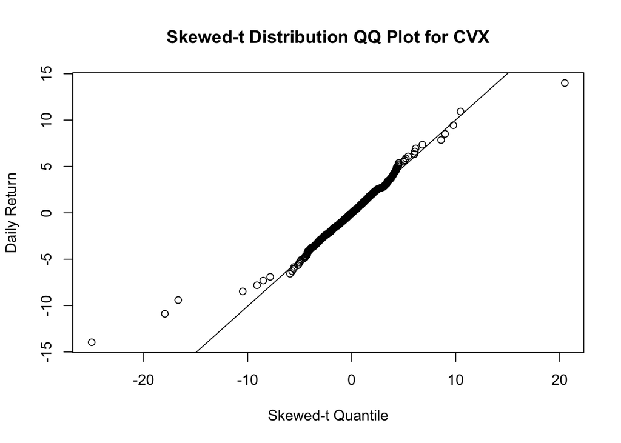

```r
s_Rt = sort(as.numeric(Rt))
grid = (1:n)/(n+1)

#QQ plot of GED
qqplot(s_Rt, qdist("std",grid,mu=fits[[2]]$pars[1],sigma=fits[[2]]$pars[2],skew=fits[[2]]$pars[3],shape=fits[[2]]$pars[4]),main='Skewed-t Distribution QQ Plot for CVX',ylab='Daily Return',xlab='Skewed-t Quantile')

lmfit = lm(qdist("std",c(.25,.75),mu=fits[[2]]$pars[1],sigma=fits[[2]]$pars[2],skew=fits[[2]]$pars[3],shape=fits[[2]]$pars[4]) ~ quantile(s_Rt,c(.25,.75)))

abline(lmfit)
```

This fit appears to fit relatively well, with the exception of a few outliers.

Fit an ARMA + GARCH

```r
k = 3
aic = bic = matrix(ncol = k, nrow = k);
dimnames(aic)[[1]] = dimnames(aic)[[2]] = as.character(0:(k-1))
dimnames(bic)[[1]] = dimnames(bic)[[2]] = as.character(0:(k-1))
for(i in 0:(k-1)){
for(j in 0:(k-1)){
out = arima(Rt[1:n,], order = c(i,0,j), include.mean = FALSE)
aic[i+1,j+1] = out$aic
bic[i+1,j+1] = -2*out$loglik + log(n)*(length(out$coef) + 1)
}
}
cat("aic for p,q = 0,1,2:\n");aic;cat("\nmodel selected by aic:\t",
paste(c("p","q"), which(aic == min(aic), arr.ind = T)-1, sep = " = "));
```

```
## aic for p,q = 0,1,2:
```

```
##          0        1        2
## 0 9130.633 9107.283 9070.204
## 1 9101.295 9087.738 9071.828
## 2 9073.136 9075.103 9068.509
```

```
##
## model selected by aic:    p = 2 q = 2
```

```r
cat("\nbic for p,q = 0,1,2:\n"); bic;cat("\nmodel selected by bic:\t",
paste(c("p","q"), which(bic == min(bic), arr.ind = T)-1, sep = " = "));
```

```
##
## bic for p,q = 0,1,2:
```

```
##          0        1        2
## 0 9136.393 9118.803 9087.484
## 1 9112.815 9105.018 9094.868
## 2 9090.416 9098.143 9097.309
```

```
##
## model selected by bic:    p = 0 q = 2
```

AIC selects ARMA(2,2). BIC selects MA(2).

```r
#returns appear stationary, d=0
fita = arima(Rt, order = c(2, 0, 2))
cat("The model chosen by the AICc:\n"); fita
```

```
## The model chosen by the AICc:
```

```
##
## Call:
## arima(x = Rt, order = c(2, 0, 2))
##
## Coefficients:
##          ar1      ar2      ma1     ma2  intercept
##       0.1451  -0.4504  -0.2328  0.5875     0.0164
## s.e.  0.0867   0.1166   0.0782  0.1064     0.0358
##
## sigma^2 estimated as 2.787:  log likelihood = -4529.15,  aic = 9070.3
```

```r
fitb = arima(Rt, order = c(0, 0, 2))
cat("\nThe model chosen by the BIC:\n"); fitb
```

```
##
## The model chosen by the BIC:
```

```
##
## Call:
## arima(x = Rt, order = c(0, 0, 2))
##
## Coefficients:
##           ma1     ma2  intercept
##       -0.1003  0.1361     0.0161
## s.e.   0.0204  0.0214     0.0357
##
## sigma^2 estimated as 2.794:  log likelihood = -4532,  aic = 9072
```

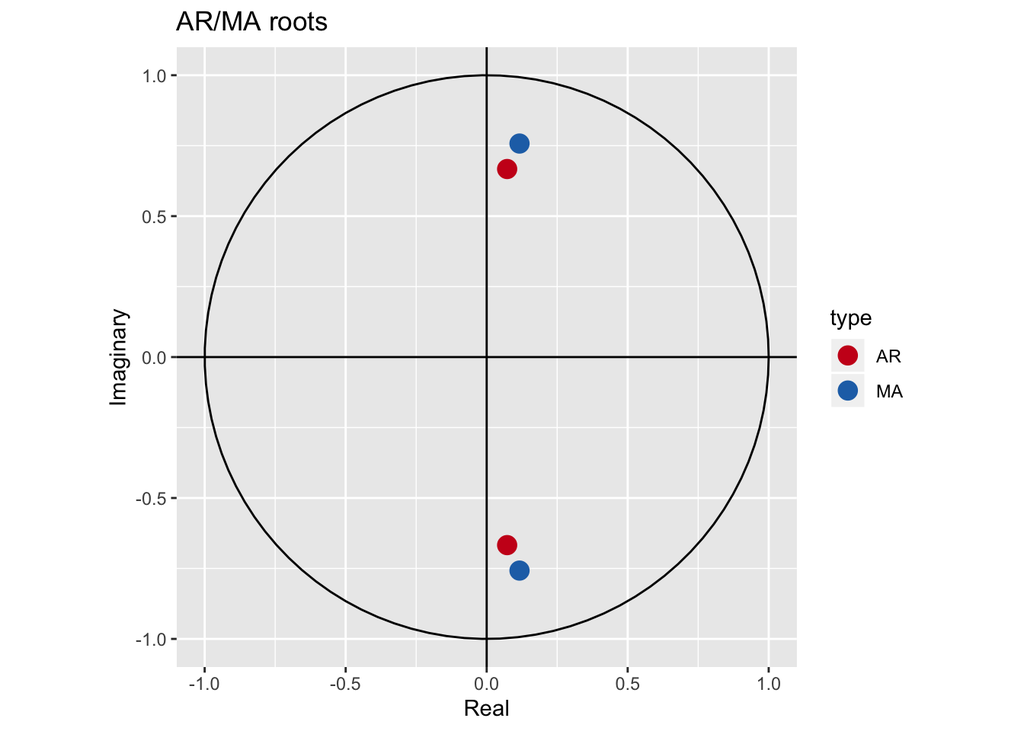

```r
autoplot_roots(phi = fita$model$phi, theta = fita$model$theta)
```

The ARMA(2,2) model has common roots, thus do not use. Move forward with MA(2) model.

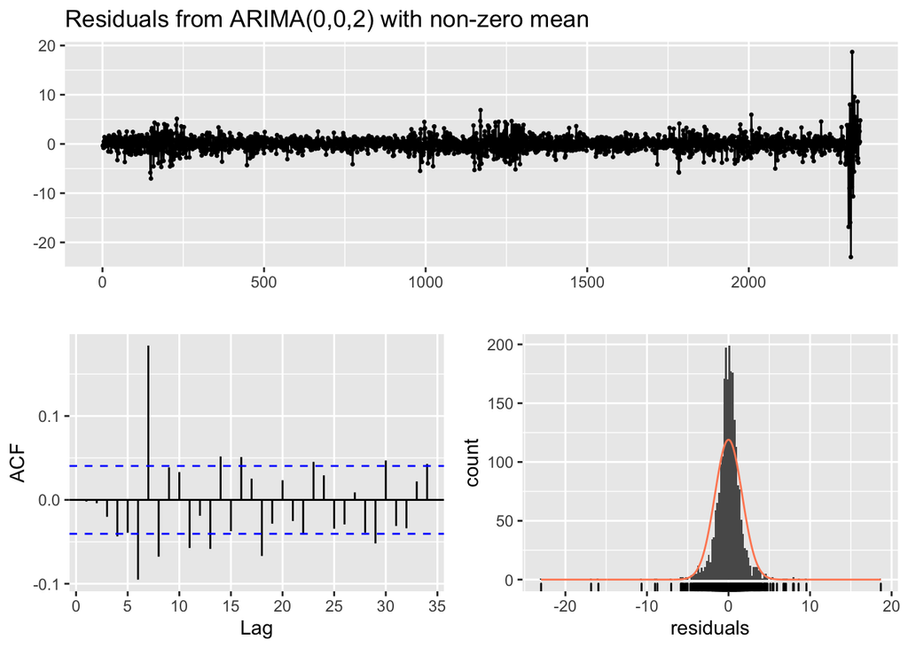

```
##
##  Ljung-Box test
##
## data:  Residuals from ARIMA(0,0,2) with non-zero mean
## Q* = 126.95, df = 7, p-value < 2.2e-16
##
## Model df: 3.   Total lags used: 10
```

```r
#check residuals
DF = round(log(length(Rt)))
checkresiduals(fitb, lag = DF + length(fitb$model$phi) + length(fitb$model$theta))
```

Ljung-Box and ACF show remaining correlation but that may be due to ARCH effects.

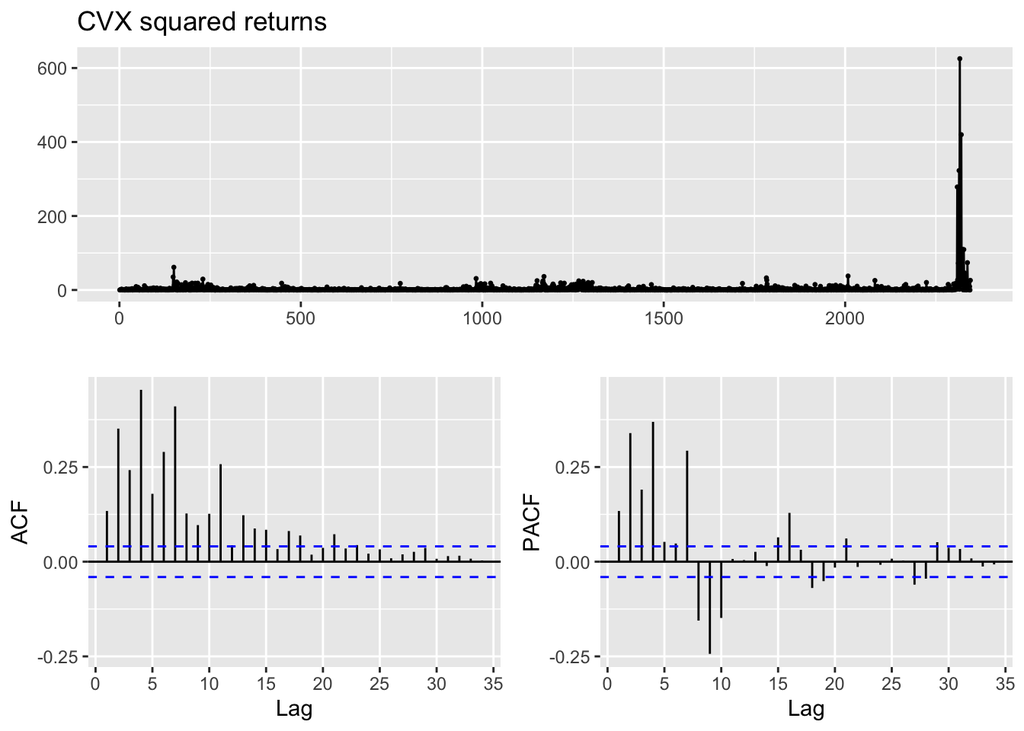

```r
ggtsdisplay(Rt^2, main = "CVX squared returns")
```

The squared returns ACF and PACF show significant remaining persistent autocorrelation, which further confirms GARCH is required.

```r
#compare standard GARCH and extended GARCH
ic = ic.fun(Rt, arma = c(0,2), var.model = c("sGARCH", "eGARCH"), dist = c("sstd"))
```

```
##
##  Model Selected by AIC
## --------------------------
##        p q      aic dist
## sGARCH 1 1 3.256956 sstd
## eGARCH 1 1 3.239618 sstd
##
##  Model Selected by BIC
## --------------------------
##        p q      bic dist
## sGARCH 1 1 3.274150 sstd
## eGARCH 1 1 3.259268 sstd
##
## running time: 16.896 sec elapsed
```

AIC and BIC select eGarch (1,1)

```r
spec = ugarchspec(variance.model = list(model = "eGARCH", garchOrder = c(1,1)),
                  mean.model = list(armaOrder = c(0,2), include.mean = F),
                  distribution.model = "sstd")

fit.bic = ugarchfit(Rt, spec = spec)
showShort(fit.bic)
```

```
##
## *---------------------------------*
## *          GARCH Model Fit        *
## *---------------------------------*
## GARCH Model  : eGARCH(1,1)
## Mean Model   : ARFIMA(0,0,2)
## Distribution : sstd
##
## Optimal Parameters
## ------------------------------------
##         Estimate  Std. Error   t value Pr(>|t|)
## ma1    -0.008249    0.020259  -0.40719 0.683868
## ma2    -0.011583    0.020376  -0.56847 0.569715
## omega   0.008288    0.002502   3.31241 0.000925
## alpha1 -0.091722    0.012283  -7.46719 0.000000
## beta1   0.984422    0.001282 768.16611 0.000000
## gamma1  0.133698    0.020028   6.67561 0.000000
## skew    0.897332    0.025639  34.99859 0.000000
## shape   6.037837    0.711958   8.48061 0.000000
##
## LogLikelihood : -3790.452
##
## Information Criteria
## ------------------------------------
##  Akaike  Bayes Shibata Hannan-Quinn
##  3.2396 3.2593  3.2396       3.2468
##
## Weighted Ljung-Box Test on Standardized Residuals
## ------------------------------------
##                         statistic p-value
## Lag[1]                     0.4069  0.5235
## Lag[2*(p+q)+(p+q)-1][5]    2.4179  0.8202
## Lag[4*(p+q)+(p+q)-1][9]    5.6956  0.3095
## d.o.f=2
## H0 : No serial correlation
##
## Weighted Ljung-Box Test on Standardized Squared Residuals
## ------------------------------------
##                         statistic p-value
## Lag[1]                     0.0521  0.8194
## Lag[2*(p+q)+(p+q)-1][5]    1.2480  0.8015
## Lag[4*(p+q)+(p+q)-1][9]    6.7340  0.2225
## d.o.f=2
##
## Weighted ARCH LM Tests
## ------------------------------------
##             Statistic Shape Scale P-Value
## ARCH Lag[3]   0.05889 0.500 2.000 0.80826
## ARCH Lag[5]   1.56885 1.440 1.667 0.57439
## ARCH Lag[7]   7.37112 2.315 1.543 0.07217
```

Ljung-Box and LM tests confirm no remaining correlation or ARCH effects. Final model is MA(2) + eGARCH(1,1) with estimates in above output.

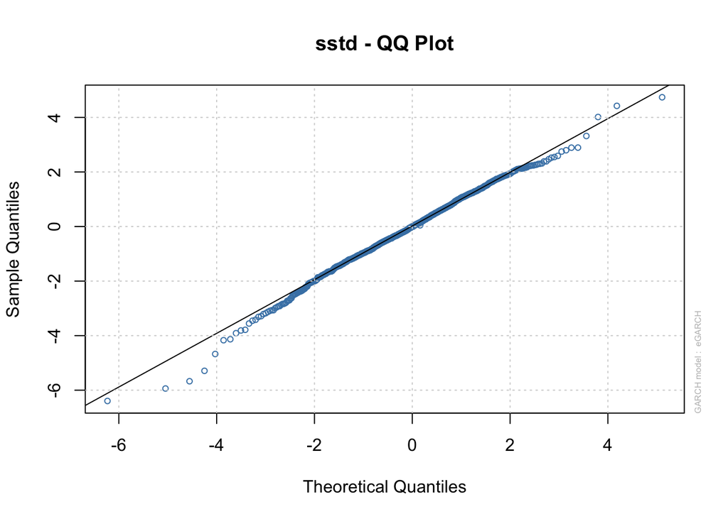

```r
#check residuals
plot(fit.bic,which=9)
```

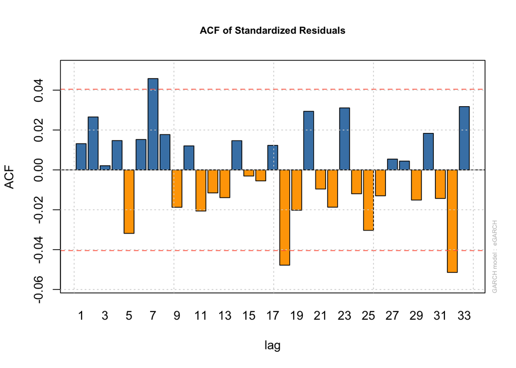

```r
plot(fit.bic,which=10)
```

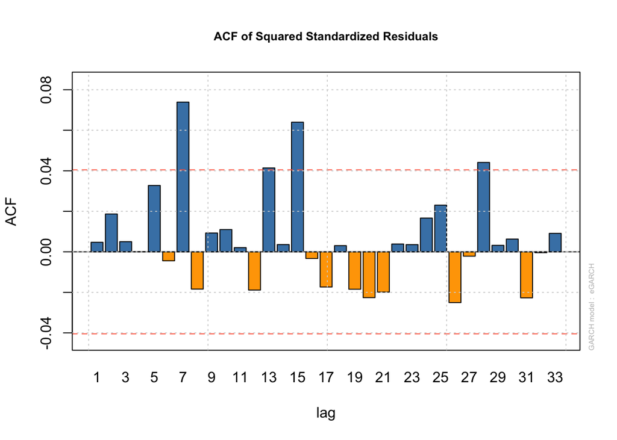

```r
plot(fit.bic,which=11)
```

Assuming today is 04-29-2020, use selected model to forecast tomorrow and day after tomorrow’s returns (1-step and 2-step). Include both point and 95% interval forecasts.

```r
#point forecasts
fore = ugarchforecast(fit.bic, n.ahead = 2)
cat("h-step daily return forecast, h = 1-2:\n");fitted(fore);
```

```
## h-step daily return forecast, h = 1-2:
```

```
##      2020-04-29
## T+1 -0.04534933
## T+2 -0.05958144
```

```r
#95% interval forecasts
cri = qdist("std",p = .975, shape = coef(fit.bic)["shape"])
cat("95% Prediction intervals:\n");cbind(fitted(fore)-cri*sigma(fore),
fitted(fore)+sigma(fore))
```

```
## 95% Prediction intervals:
```

```
##     2020-04-29 2020-04-29
## T+1  -6.586874   3.228708
## T+2  -6.508022   3.167887
```